## MA2102

# Probability and Statistics

#### Lecture-11

# Types of Random Variables

Let $X$ be a random variable defined on $(\Omega,\mathscr{F},P)$, and $(\mathbb{R},\mathscr{B},P^X)$ be induced probability space by $X$, then $CDF$ $F_X$ will be either continuous everywhere or it will have countably many (finite/countably infinite) (jump)discontinuities where the sum of jump lengths at the point of discontinuities always $\le$1. We will use these properties to classify random variables.

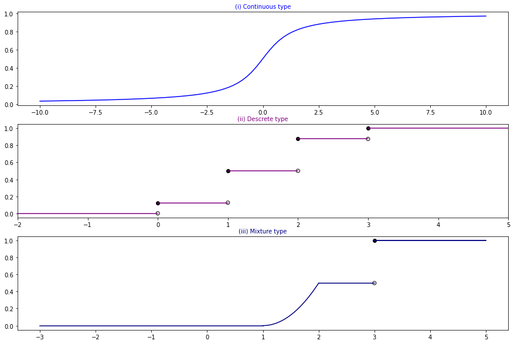

```python
import matplotlib.pyplot as plt
import numpy as np
x=np.linspace(-10,10,100)
fig, ax = plt.subplots(3,1,figsize=(15,10))
# Continuous type example CDF Plot
ax[0].plot(x,1/2+(1/np.pi)*np.arctan(x),color='blue')
ax[0].set_title("(i) Continuous type",fontsize=10,color='blue')

# Discrete type exmaple CDF Plot
x1=[0,1,2,3]
y1=[0,1/8,1/2,7/8]
x2=[0,1,2,3]
y2=[1/8,1/2,7/8,1]
ax[1].scatter(x1,y1,facecolors='none', edgecolors='black')
ax[1].scatter(x2,y2,facecolors='black', edgecolors='black')
ax[1].set_xlim(-2,5)
ax[1].plot([-2,0],[0,0],color='purple')
ax[1].plot([0,1],[1/8,1/8],color='purple')
ax[1].plot([1,2],[1/2,1/2],color='purple')
ax[1].plot([2,3],[7/8,7/8],color='purple')
ax[1].plot([3,5],[1,1],color='purple')
ax[1].set_title("(ii) Descrete type",fontsize=10,color='purple')

# Mixture Type example CDF Plot
ax[2].plot([-3,1],[0,0],color='navy')
xx=np.linspace(1,2,50)
ax[2].plot(xx,(xx-1)*(xx-1)/2,color='navy')
ax[2].plot([2,3],[1/2,1/2],color='navy')
ax[2].plot([3,5],[1,1],color='navy')
ax[2].scatter([3],[1/2],facecolors='none', edgecolors='black')
ax[2].scatter([3],[1],facecolors='black', edgecolors='black')
ax[2].plot([3,5],[1,1],color='navy')
ax[2].set_title("(iii) Mixture type",fontsize=10,color='navy')
# ax[0].set_xticks([])

plt.show()
```

**Definition:** A random variable $X$ is said to be of discrete type if it's $CDF$ has countably many discontinuities with sum of jump at the point of discontinuities exactly equals to $1$.

For discrete type random variable $X$, there exist a countable set(finite/countably infinite) $S_X$(set of discontinuities of $F_X$) such that $P(X=x)=F_X(x)-F_X(x-)>0~\forall x\in S_X$, and $\sum_{x\in S_X}\underbrace{(F_X(x)-F_X(x-))}_{\text{jump length at $x$}}=1$. This set $S_X$ is called the support of $X$

**Note:** Discrete random variable can take only countably many values that are precisely discontinuities of its $CDF$, and $P(X\in S_X)=1$ and $P(X\in S_X^c)=0$

For any $B\in\mathscr{B}$, $P^X(B)=P^X(B\cap S_X)$

$=P^X(\cup_{x\in B\cap S_X}\{x\})$

$=\sum_{x\in B\cap S_X}P^X(\{x\})$

$P^X(B)=\sum_{x\in B\cap S_X}P(X=x)$

So, for discrete type random variable $X$, the probability distribution $P^X$ will be completely determined once we know $P(X=x)~\forall x\in S_X$

and we can get $CDF$ $F_X$ with the knowledge of these countably many probabilities $P(X=x)$ for $x\in S_X$

$F_X(x)=\sum_{a\in S_X;a\le x}P(X=a)$, $x\in\mathbb{R}$

Now, we define an important function related to discrete type random variable, called the Probability mass function($PMF$)

**Definition**:Let $X$ be a discrete type random variable with support $S_X$, the function $p_X:\mathbb{R}\to\mathbb{R}$,defined by $p_X(x)=\left\{\begin{matrix} P(X=x)&x\in S_X \\ 0& \text{otherwise} \end{matrix}\right.$

is called the Probability mass function($PMF$) of $X$

**Note**:$PMF$ $p_X$of discrete random variable $X$ will completely determine the probability distribution $P^X$

In a random experiment of tossing a fair coin $3$ times

$\Omega=\{HHH,HHT,HTH,THH,HTT,THT,TTH,TTT\}$

Let $X$ denote the number of heads,then $X$ can take values 0,1,2,3

for $x<0$, $(X\le x)=\emptyset \Rightarrow F_X(x)=P(X\le x)=P(\emptyset)=0$

for $0\le x< 1$, $(X\le x)=\{TTT\} \Rightarrow F_X(x)=P(X\le x)=P(\{TTT\})=\frac{1}{8}$

for $1\le x< 2$, $(X\le x)=\{TTT,TTH,THT,HTT\} \Rightarrow F_X(x)=P(X\le x)=P(\{TTT,TTH,THT,HTT\})=\frac{1}{2}$

for $2\le x< 3$, $(X\le x)=\{TTT,TTH,THT,HTT,HHT,HTH,THH\}$  
$F_X(x)=P(X\le x)=P(\{TTT,TTH,THT,HTT,HHT,HTH,THH\})=\frac{7}{8}$

for $x \ge 3$, $(X\le x)=\Omega$  
$F_X(x)=P(X\le x)=P(\Omega)=1$

$F_X(x)=\left\{\begin{matrix} 0&x<0 \\ \frac{1}{8}&0\le x<1 \\ \frac{1}{2}&1\le x<2 \\ \frac{7}{8}&2\le x<3 \\ 1& x\ge 3 \end{matrix}\right.$

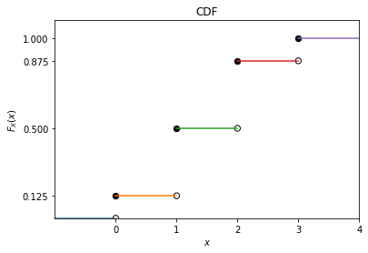

```python
import matplotlib.pyplot as plt
fig, ax = plt.subplots()
ax.scatter([0,1,2,3], [1/8,1/2,7/8,1],s=40,facecolors='black')
ax.scatter([0,1,2,3], [0,1/8,1/2,7/8],s=40,facecolors='none', edgecolors='black' )
x=[-1,0,1,2,3,4]
y=[0,1/8,1/2,7/8,1]
for i in range(0,5):
    ax.plot([x[i],x[i+1]],[y[i],y[i]])
ax.set_xlim(-1,4)
ax.set_ylim(0,1.1)
ax.set_xticks([0,1,2,3,4])
ax.set_yticks([1/8,1/2,7/8,1])
ax.set_xlabel('$x$')
ax.set_ylabel('$F_X(x)$')
ax.set_title("CDF")
plt.show()
```

Here $S_X=\{0,1,2,3\}$

$P(X=0)=F_X(0)-F_X(0-)=\frac{1}{8}-0=\frac{1}{8}$ $=\binom{3}{0}\frac{1}{2^3}$

$P(X=1)=F_X(1)-F_X(1-)=\frac{1}{2}-\frac{1}{8}=\frac{3}{8}$ $=\binom{3}{1}\frac{1}{2^3}$

$P(X=2)=F_X(2)-F_X(2-)=\frac{7}{8}-\frac{1}{2}=\frac{3}{8}$ $=\binom{3}{2}\frac{1}{2^3}$

$P(X=3)=F_X(3)-F_X(3-)=1-\frac{7}{8}=\frac{1}{8}$ $=\binom{3}{3}\frac{1}{2^3}$

$\therefore$ $PMF$ of $X$ $p_X(x)=\left\{\begin{matrix} \binom{3}{x}\frac{1}{2^3}& x=0,1,2,3\\ 0& \text{otherwise} \end{matrix}\right.$

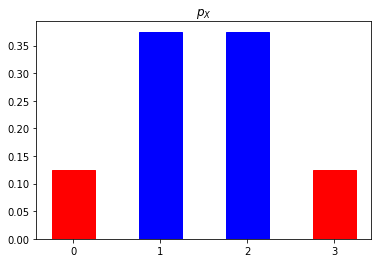

```python
import matplotlib.pyplot as plt
fig, ax = plt.subplots()
px=[1/8,3/8,3/8,1/8]
x=['0','1','2','3']
bar_list=ax.bar(x,px,width=0.5)
bar_list[0].set_color('r')
bar_list[1].set_color('b')
bar_list[2].set_color('b')
bar_list[3].set_color('r')
ax.set_title("$p_X$")
plt.show()
```

**Properties of PMF of $X$:**

- $p_X(x)>0~\forall x\in S_X$ and $p_X(x)=0~\forall x\in S_X^c$
- $\sum_{x\in S_X}p_X(x)=1$

For $B\in\mathscr{B}$, $P^X(B)=\sum_{x\in B\cap S_X}p_X(x)$

so we can study probability distribution of discrete random variable $X$ through the study of it's $PMF$ $p_X$

We also have,  
$F_X(x)=\sum_{a\in S_X;a\le x}p_X(a)$, $x\in\mathbb{R}$, and $p_X(a)=P(X=a)=F_X(a)-F_X(a-)$

Thus, given $p_X$, we can find $F_X$ and vice-versa.

**Theorem**: Suppose $\emptyset \neq S\subset \mathbb{R}$ is countable set and $g:\mathbb{R}\to\mathbb{R}$ satisfying (i)$~g(x)>0~\forall x\in S$ and $g(x)=0~\forall x\in S^c$, (ii)$\sum_{x\in S}g(x)=1$. Then $g$ will be $PMF$ for some random variable.

*proof*: Define $P:\mathscr{B}\to\mathbb{R}$, with mapping $B\mapsto \sum_{x\in B\cap S}g(x)$

we can easily verify that $P$ actually a probability measure(satisfies three axioms), that is $(\mathbb{R},\mathscr{B},P)$ is a probability space

now, define $X:\mathbb{R}\to \mathbb{R}$ with mapping $x\mapsto x$

So, $X$ is a random variable on probability space $(\mathbb{R},\mathscr{B},P)$, and it induces the same probability space $(\mathbb{R},\mathscr{B},P)$ (i.e $P^X=P$)

and it is easy to see that $P(X=x)=g(x),x\in \mathbb{R}$

$\therefore$ $X$ is a discrete random variable with support $S$ and $PMF$ $g$

**Example:** A random variable $X$ has the $CDF$,

$F_X(x)=\left\{\begin{matrix} 0&x<2 \\ \frac{2}{3}&2\le x<5 \\ \frac{7-6k}{6}&5\le x<9 \\ \frac{3k^2-6k+7}{6}& 9\le x<14 \\ \frac{16k^2-16k+19}{16}& 14\le x\le20 \\ 1& x>20 \end{matrix}\right.$

where $k\in \mathbb{R}$

(i) Find $k$

(ii)Show that $X$ is discrete type and find its support

(iii) Find the PMF of $X$

*solution:* (i) Since $F_X(X)$ is right continuous,we have $F_X(20)=F_X(20+)$

$\frac{16k^2-16k+19}{16}=1$ ($\because$ $F_X(20)=\frac{16k^2-16k+19}{16}$ and $F_X(20+)=1$ )

$16k^2-16k+3=0$ $\Rightarrow~k=\frac{1}{4} ~\text{or}~ k=\frac{3}{4}$

and also $F_X(x)$ is non-decreasing, so we must have $F_X(5-)\le F_X(5+)=F_X(5)$

$\frac{2}{3}\le \frac{7-6k}{6}$ $\Rightarrow~k\le \frac{1}{2}$, so we should take $k=\frac{1}{4}$

$\therefore~k=\frac{1}{4}$

$F_X(x)=\left\{\begin{matrix} 0&x<2 \\ \frac{2}{3}&2\le x<5 \\ \frac{11}{12}&5\le x<9 \\ \frac{91}{96}& 9\le x<14\\ 1 & x\ge 14 \end{matrix}\right.$

(ii)

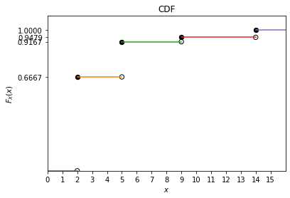

```python
import matplotlib.pyplot as plt
fig, ax = plt.subplots()
ax.scatter([2,5,9,14], [2/3,11/12,91/96,1],s=40, facecolors='black' )
ax.scatter([2,5,9,14], [0,2/3,11/12,91/96],s=40,facecolors='none', edgecolors='black')
x=[0,2,5,9,14,16]
y=[0,2/3,11/12,91/96,1]
for i in range(0,5):
    ax.plot([x[i],x[i+1]],[y[i],y[i]])
ax.set_xlim(0,16)
ax.set_ylim(0,1.1)
ax.set_xticks([x for x in range(0,16)])
ax.set_yticks([2/3,11/12,91/96,1])
ax.set_xlabel('$x$')
ax.set_ylabel('$F_X(x)$')
ax.set_title("CDF")
plt.show()
```

$CDF$ has finitely many discontinuities that are 2,5,9,14 and sum of jump lengths at these discontinuities equals to 1(clear from figure). So $X$ is discrete type random variable. and support of $X$ is $S_X=\{2,5,9,14\}$

(iii)

$P(X=2)=F_X(2)-F_X(2-)=\frac{2}{3}-0=\frac{2}{3}$

$P(X=5)=F_X(5)-F_X(5-)=\frac{11}{12}-\frac{2}{3}=\frac{1}{4}$

$P(X=14)=F_X(14)-F_X(14-)=1-\frac{91}{96}=\frac{5}{96}$

$\therefore~PMF$ of $X$, $p_X(x)=\left\{\begin{matrix} \frac{2}{3}& x=2 \\ \frac{1}{4}& x=5 \\ \frac{1}{32}& x=9 \\ \frac{5}{96}& x=14 \\ 0& \text{otherwise} \end{matrix}\right.$

**Definition:** A random variable $X$ is said to be of continuous type if it's $CDF$ is a continuous function

For the most continuous random variables, there will be a non-negative function $f_X:\mathbb{R}\to \mathbb{R}$ such that

$F_X(x)=\int_{-\infty}^{x}f_X(t)dt$

The function $f_X(x)$ is called a probability density function(PDF) of random variable $X$

- If $f_X(x)$ is also continuous function, then we will have $\frac{d}{dx}F_X(x)=f_X(x)$ ($\because$ First Fundamental Theorem of Calculus)
- For a continuous random variable $X$, support of $X$ defined as, $S_X=\{x\in \mathbb{R}:f_X(x)>0\}$
- For a continuous random variable $X$, with $PDF$ $f_X$, $P(a<X\le b)=P(a\le X< b)=P(a<X< b)=P(a\le X\le b)=\int_{a}^{b}f_X(t)dt$

*proof:* Here $CDF$ is continuous as $X$ is continuous random variable, and in particular $F_X(x)$ will be continuous at $a,b$, then we have  
$P(a<X\le b)=P(a\le X< b)=P(a<X< b)=P(a\le X\le b)=F_X(b)-F_X(a)$

$=\int_{-\infty}^{b}f_X(t)dt-\int_{-\infty}^{a}f_X(t)dt=\int_{a}^{b}f_X(t)dt$

$=\int_{-\infty}^{a}f_X(t)dt+\int_{a}^{b}f_X(t)dt-\int_{-\infty}^{a}f_X(t)dt=\int_{a}^{b}f_X(t)dt$

and $F_X(b)-F_X(a)=\int_{-\infty}^{b}f_X(t)dt-\int_{-\infty}^{a}f_X(t)dt$

**Note:** Since $f_X(x)$ is non-negative function,the integral of $f_X(x)$ can be interpreted as area under the curve.

$P(a<X\le b)=P(a\le X< b)=P(a<X< b)=P(a\le X\le b)=$Area under the curve $f_X(x)$ over interval $[a,b]$

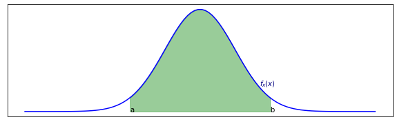

```python
import matplotlib.pyplot as plt
import numpy as np
from scipy.stats import norm
x=np.linspace(-5,5,100)
xx=np.linspace(-2,2,50)
fig, ax = plt.subplots(figsize=(10,3))

ax.plot(x,norm.pdf(x),color='blue')
ax.fill_between(xx,norm.pdf(xx),alpha=0.4,color='green')
ax.set_xticks([])
ax.set_yticks([])
ax.text(-2,0,"a")
ax.text(2,0,"b")
ax.text(1.7,0.1,r"$f_x(x)$",color='navy')
plt.show()
```

$\int_{-\infty}^{\infty}f(t)dt=\lim_{x\to \infty}\int_{-\infty}^{x}f(t)dt=\lim_{x\to \infty}F_X(x)=F_X(\infty)=1$

$\therefore$ Total area under the $PDF$ curve $f_X(x)$ is equal to 1

**Properties of PDF:**

(i) $f_X(x)\ge0~\forall x\in\mathbb{R}$

(ii)$\int_{-\infty}^{\infty}f_X(t)dt=1$

In advanced course on probability theory, it can be shown that if a function satisfies the above (i),(ii) properties, then it is a $PDF$ for some random variable.

**Note:** for $x_0\in S_X$

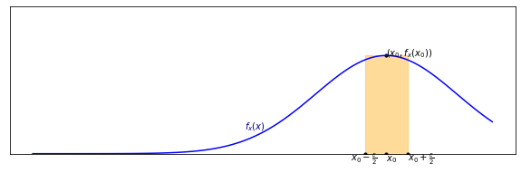

```python
import matplotlib.pyplot as plt
import numpy as np
from scipy.stats import norm
x=np.linspace(-5,1.5,100)
fig, ax = plt.subplots(figsize=(10,3))

ax.plot(x,norm.pdf(x),color='blue')
ax.fill_between([-0.3,0.3],norm.pdf([0,0]),alpha=0.4,color='orange')
ax.set_xticks([])
ax.set_yticks([])
ax.set_ylim(0,0.6)
ax.scatter([-0.3,0,0.3],[0,0,0],facecolors='black',s=10)
ax.scatter([0],[norm.pdf(0)],facecolors='black',s=10)
ax.text(0,-0.03,r"$x_0$")
ax.text(-0.5,-0.03,r"$x_0-\frac{\epsilon}{2}$")
ax.text(0.3,-0.03,r"$x_0+\frac{\epsilon}{2}$")
ax.text(0,norm.pdf(0),r"$(x_0,f_x(x_0))$")
ax.text(-2,0.1,r"$f_x(x)$",color='navy')
plt.show()
```

$P(x_0-\frac{\varepsilon}{2}<X<x_0+\frac{\varepsilon}{2})=\int_{x_0-\frac{\varepsilon}{2}}^{x_0+\frac{\varepsilon}{2}}f(t)dt\approx f_X(x_0)\varepsilon$

So, $f_X(x_0)$ is a measure of how likely it is that the random variable will be near x_0

Please note that $f_X(x_0)$ is not $P(X=x_0)$(actually for continuous random variables $P(X=x)=0\forall x$)

- Let $X$ be a continuous random variable with $PDF$ $f_X(x)$, for $B\in \mathscr{B}$, then $P^X(B)=P(X\in B)=\int_{B}f_X(t)dt$

Let us consider the random experiment of selecting a point in the interior of unit circle

Sample space $\Omega=\{(a,b)\in\mathbb{R}^2:a^2+b^2<1\}$

For event $A\subseteq\Omega$,$P(A)=\frac{area(A)}{\pi}$

($\because$ we select point in $\Omega$ at random, so $P(A)$ should be proportional to $area(A)$

$\Rightarrow$ $P(A)=c.area(A)$, and $P(\Omega)=c.area(\Omega)=1$$\Rightarrow$ $c.\pi.1^2=1\Rightarrow~c=\frac{1}{\pi}$

Define $X:\Omega \to \mathbb{R}$ with mapping $(a,b)\mapsto distance((0,0),(a,b))=\sqrt{a^2+b^2}$

```python
%%HTML
<iframe src="https://editor.p5js.org/nagi1805/embed/taXzRKHXK" width="800" height="300"></iframe>
```

[interactive chart not shown]

Here the range of $X$ $\mathscr{X}=[0,1)$

$\{X\le x\}=\{(a,b)\in\Omega:\sqrt{a^2+b^2}\le x\}$

$CDF$ of $X$,

for $x<0$,$F_X(x)=P(X\le x)=0$

for $0\le x<1$,$F_X(x)=P(X\le x)=\frac{\pi x^2}{\pi}=x^2$

for $x\ge 1$,$F_X(x)=P(X\le x)=1$

$\therefore$ $F_X(x)=\left\{\begin{matrix} 0&x<0 \\ x^2&0\le x<1 \\ 1&x\ge 1 \end{matrix}\right.$

$PDF$ of $X$, $f_X(x)=\frac{d}{dx}F_X(x)=\left\{\begin{matrix} 2x& 0\le x<1\\ 0& \text{otherwise} \end{matrix}\right.$

Probability of selected point fall in the ring with radii $\frac{1}{4}$ and $\frac{1}{2}$ is

```python
%%HTML
<iframe src="https://editor.p5js.org/nagi1805/embed/CdWtOok09" width="400" height="300"></iframe>
```

[interactive chart not shown]

$P(\frac{1}{4}<X<\frac{1}{2})=\int_{\frac{1}{4}}^{\frac{1}{2}}2tdt=[t^2]_{\frac{1}{4}}^{\frac{1}{2}}=\frac{3}{16}$

**Example**: Let $X$ be the time in seconds between incoming telephone calls at a busy switchboard. Suppose that a reasonable probability model for $X$ is given by $PDF$, $f_X(x)=\left\{\begin{matrix} \frac{1}{4}e^{\frac{-x}{4}}& 0<x<\infty \\ 0& \text{otherwise} \end{matrix}\right.$  
then, find the probability that the time between successive phone calls exceeds 4 seconds.

*solution*:  
$P(X>4)=\int_{4}^{\infty}e^{\frac{-x}{4}}dx$

take $t=\frac{x}{4}\Rightarrow dt=\frac{dx}{4}$

$t$ vary from $1$ to $\infty$ as $x$ vary from $4$ to $\infty$

$P(X>4)=\int_{1}^{\infty}e^{-t}dt=\lim_{x\to \infty}\int_{1}^{x}e^{-t}dt$

$=lim_{x\to \infty}[-e^{-t}]_{1}^{x}=lim_{x\to \infty}[e^{-1}-e^{-x}]=e^{-1}-lim_{x\to \infty}e^{-x}=e^{-1}-0$

$\therefore$ $P(X>4)=\frac{1}{e}$

**Example:** The life time in hours of certain kind of radio tube is a random variable $X$ with $PDF$,  
$f_X(x)=\left\{\begin{matrix} 0&x\le 100 \\ \frac{100}{x^2}&x>100 \end{matrix}\right.$  
What is the probability that exactly 2 of 5 such a tubes in a radio set will have to be replaced within the first 150 hours of operation?

*solution*:  
Let $A_i$ be the event that $i^{th}$ tube in a radio set failing within first 150 hours of operation, for $i=1,2,3,4,5$

$P(A_i)=P(X<150)=\int_{-\infty}^{150}f_X(x)dx$

$=\int_{100}^{150}\frac{100}{x^2}dx=\left[\frac{-100}{x}\right ]_{100}^{150}=1-\frac{2}{3}=\frac{1}{3}$

$\therefore~P(A_i)=\frac{1}{3}\Rightarrow P(A_i^c)=\frac{2}{3}$ for $i=1,2,3,4,5$

Let $Y$ denote the number of tubes that fails in first 150 hours of operation out of 5 tubes in a radio set

$Y$ takes values $0,1,2,3,4,5$

Here we are interested in $P(Y=2)=?$

$P(Y=2)=\sum_{\{i_1,i_2\}\cup\{i_3,i_4,i_5\}=\{1,2,3,4,5\}}P(A_{i_1}\cap A_{i_2}\cap A_{i_3}^c\cap A_{i_4}^c\cap A_{i_5}^c)$

$P(Y=2)=\sum_{\{i_1,i_2\}\cup\{i_3,i_4,i_5\}=\{1,2,3,4,5\}}P(A_{i_1})P(A_{i_2})P(A_{i_3}^c)P(A_{i_4}^c)P(A_{i_5}^c)$

$P(Y=2)=\sum_{\{i_1,i_2\}\cup\{i_3,i_4,i_5\}=\{1,2,3,4,5\}}\left(\frac{1}{3}\right)^2\left(\frac{2}{3}\right)^{3}=\binom{5}{2}\left(\frac{1}{3}\right)^2\left(\frac{2}{3}\right)^{3}\approx 0.3292$

**Example**: Suppose $X$ is a continuous random variable whose $PDF$ is given by, $f_X(x)=\left\{\begin{matrix} k(4x-2x^2) &0<x<2 \\ 0& \text{otherwise} \end{matrix}\right.$

then (i) Find $k$, (ii) Find $P(X>1)$

*solution*:(i)  
Since $f_X(x)$ is $PDF$, $\int_{-\infty}^{\infty}f_X(x)=1$

$\int_{-\infty}^{0}0+\int_{0}^{2}k(4x-2x^2)+\int_{2}^{\infty}0=1\Rightarrow k\int_{0}^{2}(4x-2x^2)=1$

$k\left[2x^2-\frac{2x^3}{3}\right]=1\Rightarrow k\left[8-\frac{16}{3}\right]=1$

$k=\frac{3}{8}$

$\therefore$ $f_X(x)=\left\{\begin{matrix} \frac{3}{8}(4x-2x^2)&0<x<2 \\ 0& \text{otherwise} \end{matrix}\right.$

(ii)  
$P(X>1)=1-P(X\le 1)$

$=1-\int_{-\infty}^{1}f_X(x)$

$=1-\int_{0}^{1}\frac{3}{8}(4x-2x^2)dx=1-\frac{3}{8}\left[2x^2-\frac{2x^3}{3}\right]_{0}^{1}=\frac{1}{2}$

$\therefore$ $P(X>1)=\frac{1}{2}$